# APPDS - Statistics

HW 3 - 2022/11/10 - Schelander Martina

Prerequisites - Load libraries

```r
library(mosaic)
```

### Exercise 29

#### An engine produces wooden staff with a length of µ = 1.2 m and a standard deviation of σ = 2 cm. The length of the wooden staff follows a normal distribution.

#### Probability that the length of a randomly selected staff lies between 1175 mm and 1195 mm.

```r
ex29_mean=1200
ex29_sd=20
lower <- pnorm(1175, ex29_mean, ex29_sd)
upper <- pnorm(1195, ex29_mean, ex29_sd)
prop <- upper - lower
ex29_pct_value <- round(prop*100,2)
answer <- paste('The probability that the length of a randomly selected staff lies between 1175mm and 1195mm is',ex29_pct_value,'%')
answer
```

```
## [1] "The probability that the length of a randomly selected staff lies between 1175mm and 1195mm is 29.56 %"
```

#### Visualization

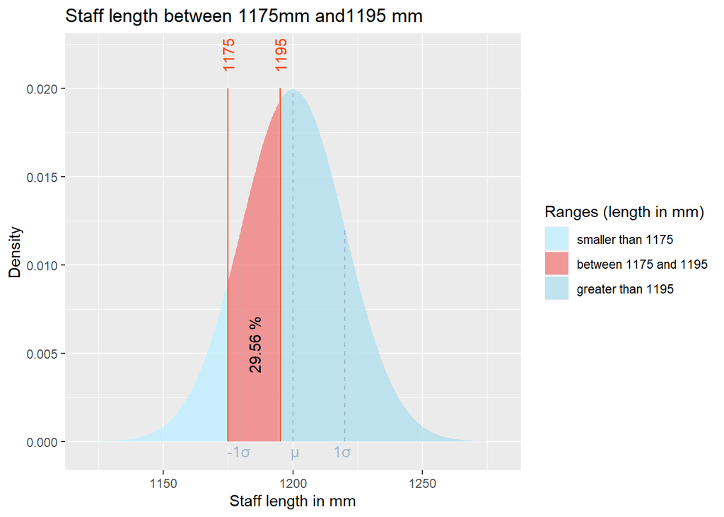

```r
colranges<-"orangered"
col_s_mu<-"lightsteelblue3"

xpnorm(c(1175, 1195),ex29_mean, ex29_sd, verbose = FALSE, xlab="Staff length in mm",
     ylab="Density", title = "Staff length between 1175mm and1195 mm", return = "plot") %>%
  gf_refine(
  scale_fill_manual( values = alpha(c("lightblue1", "lightcoral", "lightblue2"), 0.8), labels = c("smaller than 1175", "between 1175 and 1195", "greater than 1195"), name = "Ranges (length in mm)"))+
  annotate("segment", x = 1175, xend = 1175, y = 0, yend = 0.02, colour = colranges)+
  annotate("segment", x = 1195, xend = 1195, y = 0, yend = 0.02, colour = colranges)+
  annotate("text",x=1175,y=0.022,label="1175 ",angle=90, colour = colranges)+
  annotate("text",x=1195,y=0.022,label="1195 ",angle=90, colour = colranges)+
  annotate("segment", x = ex29_mean, xend = ex29_mean, y = 0, yend = 0.01995, colour = col_s_mu, linetype=2)+
  annotate("text",x=(ex29_mean + 1),y=-0.0005,label="μ", colour = col_s_mu)+
  annotate("segment", x = ex29_mean - ex29_sd, xend = ex29_mean - ex29_sd, y = 0, yend = 0.012, colour = col_s_mu, linetype=2)+
  annotate("text",x=(ex29_mean - ex29_sd - 1),y=-0.0005,label="-1σ", colour = col_s_mu)+
  annotate("segment", x = ex29_mean + ex29_sd, xend = ex29_mean + ex29_sd, y = 0, yend = 0.012, colour = col_s_mu, linetype=2)+
  annotate("text",x=(ex29_mean + ex29_sd - 1),y=-0.0005,label="1σ", colour = col_s_mu)+
  annotate("text",x=(1185),y=0.0055,angle=90,label=paste(ex29_pct_value,"%"))
```

#### Probability that the length of a randomly selected staff is longer than 1190 mm.

```r
lower <- pnorm(1190, ex29_mean, ex29_sd)
value <- round((1-lower)*100,2)
answer <- paste('The probability that the length of a randomly selected staff is longer than 1190 mm is',value,'%')
answer
```

```
## [1] "The probability that the length of a randomly selected staff is longer than 1190 mm is 69.15 %"
```

#### Visualization

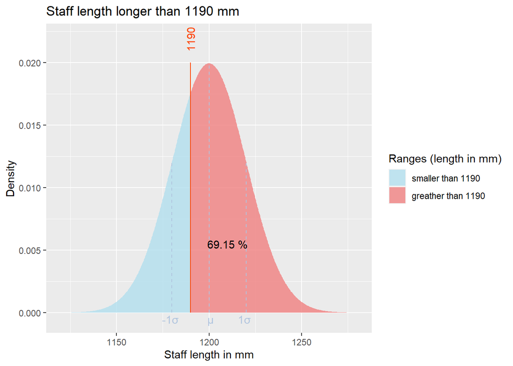

```r
colranges<-"orangered"
col_s_mu<-"lightsteelblue"

xpnorm(c(0,1190),ex29_mean, ex29_sd, verbose = FALSE, xlab= "Staff length in mm",
     ylab="Density", title = "Staff length longer than 1190 mm", return = "plot") %>%
  gf_refine(
  scale_fill_manual(values = alpha(c("lightblue2", "lightcoral"), 0.8), labels = c("smaller than 1190", "greather than 1190"), name = "Ranges (length in mm)"))+
  annotate("segment", x = 1190, xend = 1190, y = 0, yend = 0.02, colour = colranges, linetype=1)+
  annotate("text",x=1190,y=0.022,label="1190 ",angle=90, colour = colranges)+
  annotate("segment", x = ex29_mean, xend = ex29_mean, y = 0, yend = 0.01995, colour = col_s_mu, linetype=2)+
  annotate("text",x=(ex29_mean + 2 - 1),y=-0.0005,label="μ", colour = col_s_mu)+
  annotate("segment", x = ex29_mean - ex29_sd, xend = ex29_mean - ex29_sd, y = 0, yend = 0.012, colour = col_s_mu, linetype=2)+
  annotate("text",x=(ex29_mean - ex29_sd - 1),y=-0.0005,label="-1σ", colour = col_s_mu)+
  annotate("segment", x = ex29_mean + ex29_sd, xend = ex29_mean + ex29_sd, y = 0, yend = 0.012, colour = col_s_mu, linetype=2)+
  annotate("text",x=(ex29_mean + ex29_sd - 1),y=-0.0005,label="1σ", colour = col_s_mu)+
  annotate("text",x=(1210),y=0.0055,label=paste(value,"%"))
```

#### Probability that the length of a randomly selected staff shows a maximal deviation of 10 mm for the expectation.

```r
upper <- pnorm(1210, ex29_mean, ex29_sd)
lower <- pnorm(1190, ex29_mean, ex29_sd)
prop <- upper - lower
pct_value <- round(prop*100,2)
answer <- paste('The probability that the length of a randomly selected staff shows a maximal deviation of 10 mm for the expectation is',pct_value,'%')
answer
```

```
## [1] "The probability that the length of a randomly selected staff shows a maximal deviation of 10 mm for the expectation is 38.29 %"
```

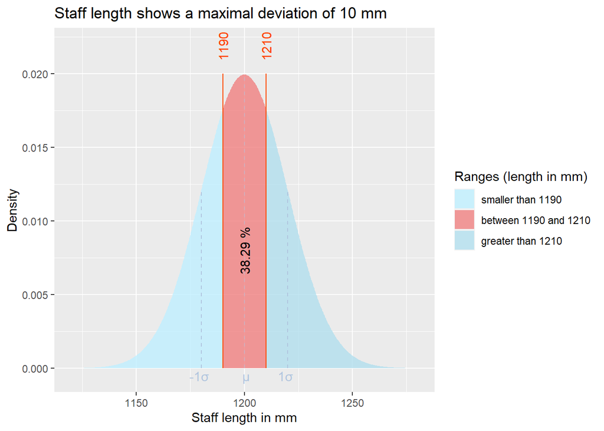

```r
colranges<-"orangered"
col_s_mu<-"lightsteelblue"

xpnorm(c(1190, 1210),ex29_mean, ex29_sd, verbose = FALSE, xlab= "Staff length in mm",
     ylab="Density", title = "Staff length shows a maximal deviation of 10 mm", return = "plot") %>%
  gf_refine(
  scale_fill_manual( values = alpha(c("lightblue1", "lightcoral", "lightblue2"), 0.8), labels = c("smaller than 1190", "between 1190 and 1210", "greater than 1210"), name = "Ranges (length in mm)")) +
  annotate("segment", x = 1190, xend = 1190, y = 0, yend = 0.02, colour = colranges, linetype=1)+
  annotate("segment", x = 1210, xend = 1210, y = 0, yend = 0.02, colour = colranges, linetype=1)+
  annotate("text",x=1190,y=0.022,label="1190 ",angle=90, colour = colranges)+
  annotate("text",x=1210,y=0.022,label="1210 ",angle=90, colour = colranges)+
  annotate("segment", x = ex29_mean, xend = ex29_mean, y = 0, yend = 0.01995, colour = alpha(col_s_mu,0.5), linetype=2)+
  annotate("text",x=(ex29_mean + 2 - 1),y=-0.0005,label="μ", colour = col_s_mu)+
  annotate("segment", x = ex29_mean - ex29_sd, xend = ex29_mean - ex29_sd, y = 0, yend = 0.012, colour = col_s_mu, linetype=2)+
  annotate("text",x=(ex29_mean - ex29_sd - 1),y=-0.0005,label="-1σ", colour = col_s_mu)+
  annotate("segment", x = ex29_mean + ex29_sd, xend = ex29_mean + ex29_sd, y = 0, yend = 0.012, colour = col_s_mu, linetype=2)+
  annotate("text",x=(ex29_mean + ex29_sd - 1),y=-0.0005,label="1σ", colour = col_s_mu)+
  annotate("text",x=(ex29_mean),y=0.008,angle=90,label=paste(pct_value,"%"))
```

## Exercise 30

#### An engine produces metal plates with a thickness of µ = 5 mm and a standard deviation of sigma = 0.3 mm. The thickness of the metal plates follows a normal distribution.

#### How many plates are useless, because their thickness is below 4.4 mm?

```r
ex30_mean<-5
ex30_sd<-0.3
value <- round(pnorm(4.4, ex30_mean, ex30_sd)*100, 2)
answer <- paste(value,"% of the plates are useless, because their thickness is below 4.4 mm.")
answer
```

```
## [1] "2.28 % of the plates are useless, because their thickness is below 4.4 mm."
```

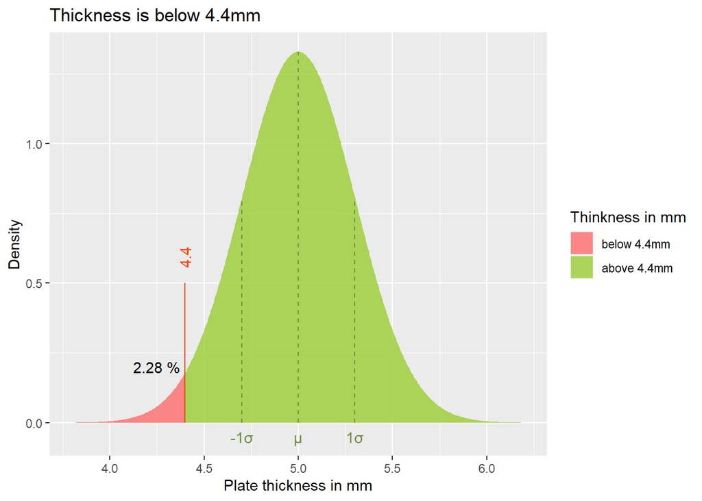

```r
colranges<-"orangered"
col_s_mu<-"darkolivegreen4"

xpnorm(c(0,4.4), ex30_mean, ex30_sd, verbose = FALSE, xlab= "Plate thickness in mm",
     ylab="Density", title = "Thickness is below 4.4mm", return = "plot") %>%
  gf_refine(scale_fill_manual( values = alpha(c("indianred1", "olivedrab3"), 0.8), labels = c("below 4.4mm", "above 4.4mm"), name = "Thinkness in mm")) +
  annotate("segment", x = 4.4, xend = 4.4, y = 0, yend = 0.5, colour = colranges, linetype=1)+
  annotate("text",x=4.4,y=0.6,label="4.4 ",angle=90, colour = colranges)+
  annotate("segment", x = ex30_mean, xend = ex30_mean, y = 0, yend = 1.33, colour = col_s_mu, linetype=2)+
  annotate("text",x=(ex30_mean),y=-0.05,label="μ", colour = col_s_mu)+
  annotate("segment", x = ex30_mean - ex30_sd, xend = ex30_mean - ex30_sd, y = 0, yend = 0.8, colour = col_s_mu, linetype=2)+
  annotate("text",x=(ex30_mean - ex30_sd),y=-0.05,label="-1σ", colour = col_s_mu)+
  annotate("segment", x = ex30_mean + ex30_sd, xend = ex30_mean + ex30_sd, y = 0, yend = 0.8, colour = col_s_mu, linetype=2)+
  annotate("text",x=(ex30_mean + ex30_sd),y=-0.05,label="1σ", colour = col_s_mu)+
  annotate("text",x=(4.25),y=0.2,label=paste(value,"%"))
```

#### How many plates are useless, because their thickness is above 5.4 mm?

```r
value = round(pnorm(5.4, ex30_mean, ex30_sd, lower.tail = FALSE)*100, 2)
answer <- paste(value,"% of the plates are useless, because their thickness is above 5.4 mm.")
answer
```

```
## [1] "9.12 % of the plates are useless, because their thickness is above 5.4 mm."
```

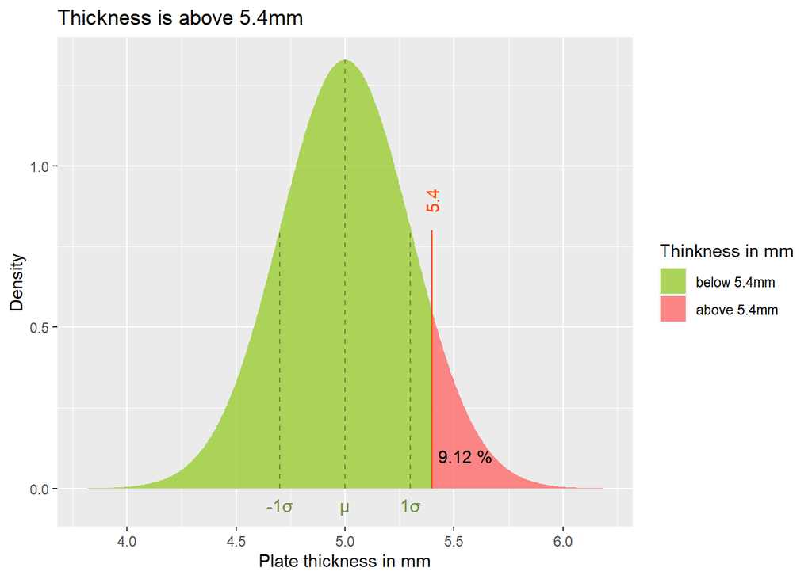

```r
colranges<-"orangered"
col_s_mu<-"darkolivegreen4"

xpnorm(c(5.4,0), ex30_mean, ex30_sd, verbose = FALSE, xlab= "Plate thickness in mm",
     ylab="Density", title = "Thickness is above 5.4mm", return = "plot") %>%
  gf_refine(scale_fill_manual( values = alpha(c("olivedrab3", "indianred1"), 0.8), labels = c("below 5.4mm", "above 5.4mm"), name = "Thinkness in mm")) +
  annotate("segment", x = 5.4, xend = 5.4, y = 0, yend = 0.8, colour = colranges, linetype=1)+
  annotate("text",x=5.4,y=0.9,label="5.4 ",angle=90, colour = colranges)+
  annotate("segment", x = ex30_mean, xend = ex30_mean, y = 0, yend = 1.33, colour = col_s_mu, linetype=2)+
  annotate("text",x=(ex30_mean),y=-0.05,label="μ", colour = col_s_mu)+
  annotate("segment", x = ex30_mean - ex30_sd, xend = ex30_mean - ex30_sd, y = 0, yend = 0.8, colour = col_s_mu, linetype=2)+
  annotate("text",x=(ex30_mean - ex30_sd),y=-0.05,label="-1σ", colour = col_s_mu)+
  annotate("segment", x = ex30_mean + ex30_sd, xend = ex30_mean + ex30_sd, y = 0, yend = 0.8, colour = col_s_mu, linetype=2)+
  annotate("text",x=(ex30_mean + ex30_sd),y=-0.05,label="1σ", colour = col_s_mu)+
  annotate("text",x=(5.55),y=0.1,label=paste(value,"%"))
```

### Exercise 32

#### A certain population has an IQ (intelligence quotient) of µ = 100 with a standard deviation of sigma = 15. The IQ follows a normal distribution.

#### What is the range of the IQ of 95% of the population?

```r
ex32_mean <- 100
ex32_sd <- 15
lower <- (1 - 0.95) / 2
upper <- (1 - 0.95) / 2 + 0.95
pct95_range <- c(qnorm(lower, ex32_mean, ex32_sd), qnorm(upper, ex32_mean, ex32_sd))
paste("The 95% range of the population ranges from an IQ of",round(pct95_range[1],0),"to an IQ of", round(pct95_range[2],0))
```

```
## [1] "The 95% range of the population ranges from an IQ of 71 to an IQ of 129"
```

#### To get a leading position, you need an IQ of more than 120. What is the percentage of people, who are not qualified for a leading position?

```r
value_under_120 <- round(pnorm(120, ex32_mean, ex32_sd)*100,2)
paste(value_under_120, "% of people are not qualified for a leading position according to their IQ level")
```

```
## [1] "90.88 % of people are not qualified for a leading position according to their IQ level"
```

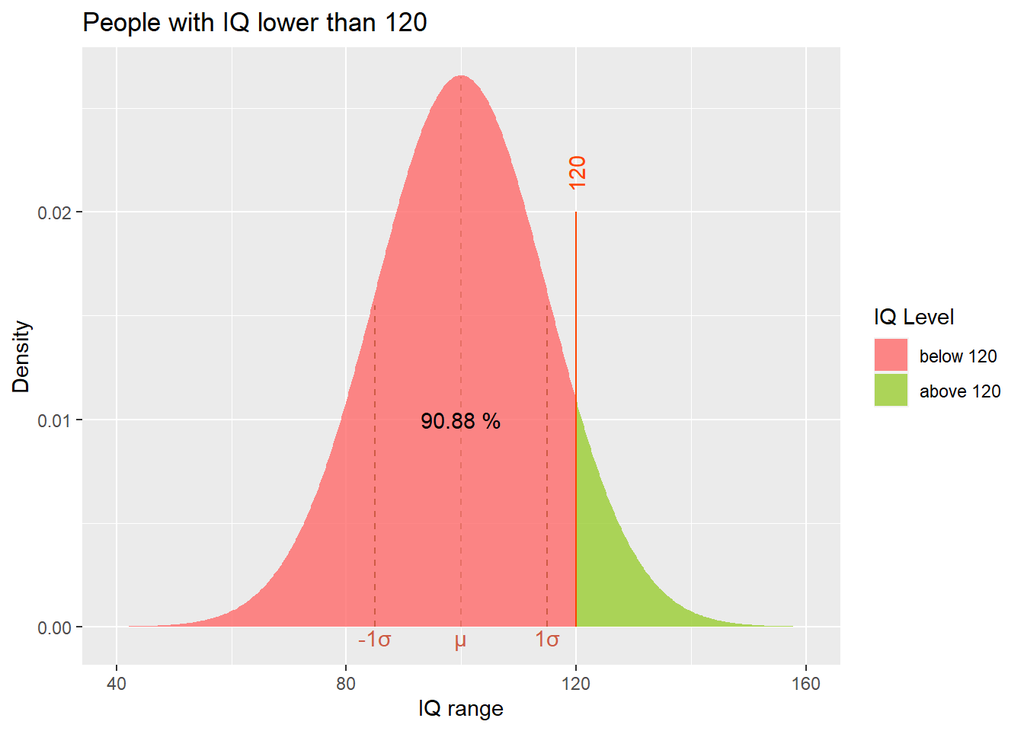

```r
colranges<-"orangered"
col_s_mu<-"coral3"

xpnorm(c(0,120), ex32_mean, ex32_sd, verbose = FALSE, xlab= "IQ range",
     ylab="Density", title = "People with IQ lower than 120", return = "plot") %>%
  gf_refine(scale_fill_manual( values = alpha(c("indianred1", "olivedrab3"), 0.8), labels = c("below 120", "above 120"), name = "IQ Level")) +
  annotate("segment", x = 120, xend = 120, y = 0, yend = 0.02, colour = colranges, linetype=1)+
  annotate("text",x=120,y=0.022,label="120 ",angle=90, colour = colranges)+
  annotate("segment", x = ex32_mean, xend = ex32_mean, y = 0, yend = 0.0265, colour = alpha(col_s_mu,0.5), linetype=2)+
  annotate("text",x=(ex32_mean),y=-0.0005,label="μ", colour = col_s_mu)+
  annotate("segment", x = ex32_mean - ex32_sd, xend = ex32_mean - ex32_sd, y = 0, yend = 0.0155, colour = col_s_mu, linetype=2)+
  annotate("text",x=(ex32_mean - ex32_sd),y=-0.0005,label="-1σ", colour = col_s_mu)+
  annotate("segment", x = ex32_mean + ex32_sd, xend = ex32_mean + ex32_sd, y = 0, yend = 0.0155, colour = col_s_mu, linetype=2)+
  annotate("text",x=(ex32_mean + ex32_sd),y=-0.0005,label="1σ", colour = col_s_mu)+
  annotate("text",x=(ex32_mean),y=0.01,label=paste(value_under_120,"%"))
```

#### What is the minimum IQ to belong to 5% of the most intelligent persons?

```r
value <- qnorm(0.95, ex32_mean, ex32_sd)
paste("To belong to the top 5% one has to have an IQ of at least", round(value))
```

```
## [1] "To belong to the top 5% one has to have an IQ of at least 125"
```

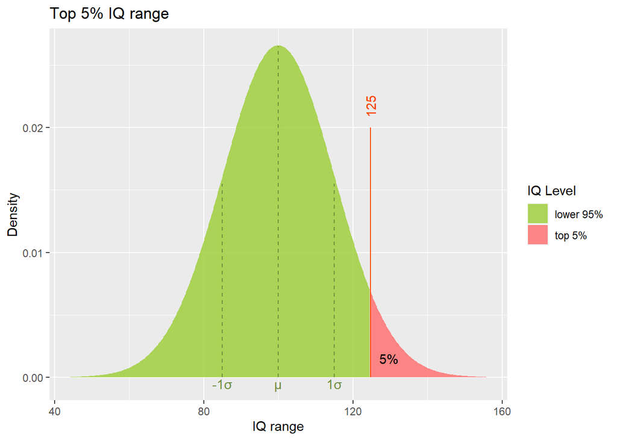

```r
colranges<-"orangered"
col_s_mu<-"darkolivegreen4"

xqnorm(c(0.95,0), ex32_mean, ex32_sd, verbose = FALSE, xlab= "IQ range",
     ylab="Density", title = "Top 5% IQ range", return = "plot") %>%
  gf_refine(scale_fill_manual( values = alpha(c("olivedrab3", "indianred1"), 0.8), labels = c("lower 95%", "top 5%"), name = "IQ Level")) +
  annotate("segment", x = value, xend = value, y = 0, yend = 0.02, colour = colranges, linetype=1)+
  annotate("text",x=value,y=0.022,label=paste(round(value)," "),angle=90, colour = colranges)+
  annotate("segment", x = ex32_mean, xend = ex32_mean, y = 0, yend = 0.0265, colour = col_s_mu, linetype=2)+
  annotate("text",x=(ex32_mean),y=-0.0005,label="μ", colour = col_s_mu)+
  annotate("segment", x = ex32_mean - ex32_sd, xend = ex32_mean - ex32_sd, y = 0, yend = 0.0155, colour = col_s_mu, linetype=2)+
  annotate("text",x=(ex32_mean - ex32_sd),y=-0.0005,label="-1σ", colour = col_s_mu)+
  annotate("segment", x = ex32_mean + ex32_sd, xend = ex32_mean + ex32_sd, y = 0, yend = 0.0155, colour = col_s_mu, linetype=2)+
  annotate("text",x=(ex32_mean + ex32_sd),y=-0.0005,label="1σ", colour = col_s_mu)+
  annotate("text",x=(value + 5),y=0.0015,label="5%")
```